# OIDD 245 Data Project 2: @mediabias u up? -Will Morgus

0.) Set-up:

```r
install.packages("data.table", repos = "https://Rdatatable.github.io/data.table", type = "source")
library(rtweet)
library(httpuv)
library(stringr)
library(tidyverse)
library(tidytext)
library(tm)
library(ggplot2)
library(reshape2)
library(data.table) #reading/writing to csv faster
library(SnowballC) #stemming
library(syuzhet) #sentiment
library(ranger) #this worked better instead of randomForest
library(class) #for the k-nearest neighbors
library(kernlab) #for the SVM
#sum of ascii values for will morgus
set.seed(1141)
setwd('/Users/willmorgus/Desktop/penn/oidd245/bias')
```

1.) Set up Rtweet

```r
#set this up ahead of time: no API keys for you!
get_token()
```

Now, testing rtweet:

```r
tmls <- get_timelines(c("cnn"), n = 50) %>% select(status_id, created_at, screen_name, text)
tmls
```

Great, it worked. To build our data sets, we’re going to collect 5000 tweets from each source, clean our data, add bias parameters, then split into training and testing sets.

While there’s a lot of [interesting reading](https://en.wikipedia.org/wiki/Media_bias#Scholarly_treatment_in_the_United_States_and_United_Kingdom) on media bias as a whole, I’m primarily going to be classifying media bias based on ratings from allsides.com, as their ratings are simple, concise, and rather widely accepted. I’m verifying these judgements with information from [Ad Fontes Media](https://www.adfontesmedia.com/how-ad-fontes-ranks-news-sources/), another rigorous bias rating site.

Let’s start building our data sets now:

```r
very_left = c("AlterNet", "democracynow", "MotherJones", "NewYorker", "MSNBC", "Slate", "Huffpost")
leans_left = c("voxdotcom", "cnn", "buzzfeednews", "thedailybeast", "nytimes", "theatlantic", "washingtonpost", "politico")
central = c("reuters", "ap", "npr", "bbcworld", "wsj", "thehill", "cbsnews", "business", "forbes", "businessinsider", "marketwatch", "theeconomist", "ft", "newsy", "csmonitor") #business is bloomberg
leans_right = c("foxnewsalert", "reason", "WashTimes", "TheIJR", "DailyMail") #pretty hard to find these...
very_right = c("BreitbartNews", "DailyCaller", "FDRLST", "NRO", "theblaze", "amconmag", "amspectator", "conserv_tribune", "pjmedia_com", "twitchyteam", "redstate")
```

(infowars got banned from twitter, or that would be a goldmine of content ¯_(ツ)_/¯)

Some quick pre-cleaning and prep:

```r
clean_text <- function(text) {
  #set uniformly to lower
  ret <- str_to_lower(text, locale="en")
  #remove punctuation to not mess with CSV
  ret <- str_remove_all(ret, "[:punct:]")
  #had some issues with \n
  ret <- str_replace_all(ret, "[:cntrl:]", " ")
  #remove hyperlinks
  ret <- str_remove_all(ret, "(http|https)[:alnum:]*(\\s|$)")
  #remove RT or via
  ret <- str_remove_all(ret, "(RT|via)[:alnum:]*(\\s|$)")
  #standardize whitespace
  ret <- str_replace_all(ret, "\\s+", " ")
  return(ret)
}

get_sentiments <- function(input_text) {
  sent <- get_sentiment(input_text, method="syuzhet")
  return(sent)
}

stem_text <- function(text) {
  new_tweets <- rep("", length(text))
  split_tweets = str_split(text, " ")
  ind = 0
  for (tweet in split_tweets) {
    ind = ind + 1
    new_str <- ""
    for (word in tweet) {
      if (word != "") {
        new_str = append(new_str, wordStem(word, language="english"))
      }
    }
    new_tweet <- paste(new_str, collapse=" ")
    #remove an extra space
    new_tweets[ind] = substring(new_tweet, 2)
  }
  return(new_tweets)
}
```

Time to actually retrieve them! This might take a while…

```r
v_l_df <- get_timelines(very_left, n = 5000, retryonratelimit = TRUE) %>% select(status_id, created_at, screen_name, text) %>%
  mutate(text=clean_text(text)) %>% mutate(sent=get_sentiment(text)) %>% mutate(text=stem_text(text)) %>% mutate(bias=0.0)
l_l_df <- get_timelines(leans_left, n = 5000, retryonratelimit = TRUE) %>% select(status_id, created_at, screen_name, text) %>%
  mutate(text=clean_text(text)) %>% mutate(sent=get_sentiment(text)) %>% mutate(text=stem_text(text)) %>% mutate(bias=0.25)
c_df <- get_timelines(central, n = 5000, retryonratelimit = TRUE) %>% select(status_id, created_at, screen_name, text) %>%
  mutate(text=clean_text(text)) %>% mutate(sent=get_sentiment(text)) %>% mutate(text=stem_text(text)) %>% mutate(bias=0.5)
l_r_df <- get_timelines(leans_right, n = 5000, retryonratelimit = TRUE) %>% select(status_id, created_at, screen_name, text) %>%
  mutate(text=clean_text(text)) %>% mutate(sent=get_sentiment(text)) %>% mutate(text=stem_text(text)) %>% mutate(bias=0.75)
v_r_df <- get_timelines(very_right, n = 5000, retryonratelimit = TRUE) %>% select(status_id, created_at, screen_name, text) %>%
  mutate(text=clean_text(text)) %>% mutate(sent=get_sentiment(text)) %>% mutate(text=stem_text(text)) %>% mutate(bias=1.0)
```

Finally, write to CSV so I don’t have to scrape 230,000 tweets every time:

```r
#write.csv(v_l_df, "./very_left.csv")
#write.csv(l_l_df, "./leans_left.csv")
#write.csv(c_df, "./central.csv")
#write.csv(l_r_df, "./leans_right.csv")
#write.csv(v_r_df, "./very_right.csv")
#fwrite is much faster than write.csv
fwrite(v_l_df, "./very_left.csv")
fwrite(l_l_df, "./leans_left.csv")
fwrite(c_df, "./central.csv")
fwrite(l_r_df, "./leans_right.csv")
fwrite(v_r_df, "./very_right.csv")
```

A read in for the next time I load:

```r
v_l_df <- fread("./very_left.csv")
l_l_df <- fread("./leans_left.csv")
c_df <- fread("./central.csv")
l_r_df <- fread("./leans_right.csv")
v_r_df <- fread("./very_right.csv")
```

Now, merge into a single dataframe and create the training/testing sets:

```r
#TODO: set up cross validation?
all_tweets_df <- rbind(v_l_df, l_l_df, c_df, l_r_df, v_r_df)
smp_size <- floor(0.75 * nrow(all_tweets_df))
train_ind <- sample(seq_len(nrow(all_tweets_df)), size = smp_size)
training_set <- all_tweets_df[train_ind, ]
test_set <- all_tweets_df[-train_ind, ]
```

1.) TF-IDF analysis of tweet text/sentiment analysis, as it relates to bias First, let’s put everything into a corpus. We’ll write a function so we can do this easily for our train and our test data. We’ll also do some basic cleaning: remove stopwords, remove numbers, standardize whitespace, remove hyperlinks, then convert to a DTM.

Also, writing another function to display the most frequent words, and how many times they appear.

```r
df_to_corp <- function(input_df) {
  corp.original = VCorpus(VectorSource(input_df$text))
  corp = tm_map(corp.original, content_transformer(tolower), lazy=TRUE)
  corp = tm_map(corp, removeWords, c(stopwords(kind = "en")))
  corp = tm_map(corp, removeNumbers)
  corp = tm_map(corp, stripWhitespace)
  return(corp)
}
```

Cool. Let’s run it on our training data, then convert that to a tf-idf

```r
train_corp = df_to_corp(training_set)
train_dtm = DocumentTermMatrix(train_corp)
train_tfidf = TermDocumentMatrix(train_corp, control = list(weighting = weightTfIdf))
train_tdm = TermDocumentMatrix(train_corp)
```

```r
tdm_df <- tidy(train_tdm) %>% mutate(document = as.numeric(document)) %>% group_by(term) %>% summarize(count_freq=sum(count)) %>% arrange(desc(count_freq))
all_words <- head(tdm_df, 3000)
all_words
```

| term | count_freq |
| --- | --- |
| trump | 16878 |
| say | 8613 |
| presid | 8360 |
| new | 7983 |
| impeach | 7758 |
| will | 6128 |
| democrat | 5687 |
| hous | 4956 |
| year | 4947 |
| report | 4838 |

[output cut: 990 more lines]

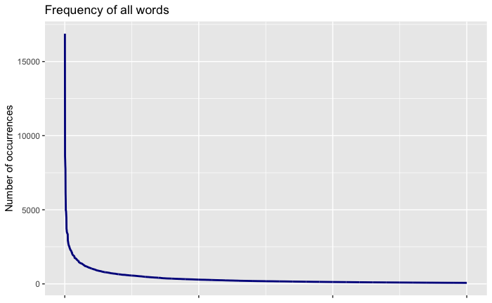

```r
ggplot(all_words, aes(x=seq_along(all_words$count_freq), y=all_words$count_freq)) +
  geom_line(colour="darkblue", size=1) +
  theme(axis.title.x=element_blank(), axis.text.x=element_blank()) +
  ylab("Number of occurrences") +
  ggtitle("Frequency of all words")
```

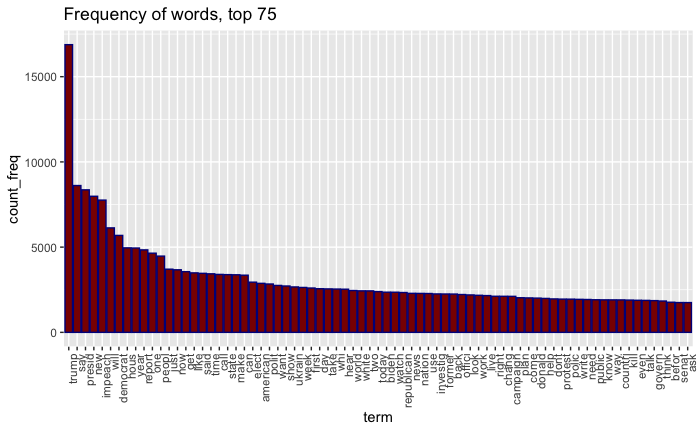

```r
top_words <- head(all_words, 75)
ggplot(top_words, aes(reorder(term, -count_freq), count_freq)) +
        geom_bar(stat="identity", fill="darkred", colour="darkblue") + xlab("term") +
        theme(axis.text.x=element_text(angle=90, hjust=1)) + ggtitle("Frequency of words, top 75")
```

We see a pretty heavy dropoff of frequency, so we can make the assumption that we should limit our vocabulary.

Let’s look at how TF-IDF values compare to just frequency. We’ll first gather the top tf-idf words:

```r
tfidf_df <- tidy(train_tfidf) %>% group_by(term) %>% summarize(tfidf_freq=sum(count)) %>% arrange(desc(tfidf_freq))
tf_all <- head(tfidf_df, 3000)
tf_all
```

| term | tfidf_freq |
| --- | --- |
| trump | 4096.1300 |
| impeach | 2714.8403 |
| say | 2499.0529 |
| new | 2417.9944 |
| presid | 2351.3211 |
| democrat | 2217.9757 |
| will | 2018.1152 |
| report | 1843.3078 |
| hous | 1782.8178 |
| year | 1738.2953 |

[output cut: 990 more lines]

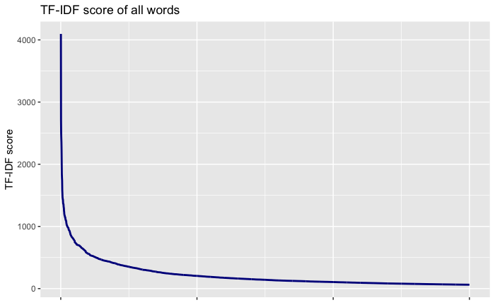

```r
ggplot(tf_all, aes(x=seq_along(tf_all$tfidf_freq), y=tf_all$tfidf_freq)) +
  geom_line(colour="darkblue", size=1) +
  theme(axis.title.x=element_blank(), axis.text.x=element_blank()) +
  ylab("TF-IDF score") +
  ggtitle("TF-IDF score of all words")
```

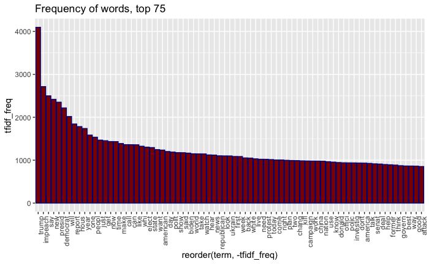

```r
top_tfidf = head(tf_all, 75)
ggplot(top_tfidf, aes(reorder(term, -tfidf_freq), tfidf_freq)) +
      geom_bar(stat="identity", fill="darkred", colour="darkblue") +
      theme(axis.text.x=element_text(angle=90, hjust=1)) + ggtitle("Frequency of words, top 75")
```

Looks pretty similar. Let’s do a side by side comparison (and account for scaling)

```r
freq_comp <- full_join(all_words, tf_all, by="term") %>% mutate_all(~replace(., is.na(.), 0))
colnames(freq_comp) = c("word", "count_freq", "tfidf_freq")
freq_comp
```

[output not shown]

[output cut: 990 more lines]

```r
freq_comp <- mutate(freq_comp, log_count_freq=log(count_freq+1)*100)
freq_comp
```

| word | count_freq | tfidf_freq | log_count_freq |
| --- | --- | --- | --- |
| trump | 16717 | 4068.2719 | 972.4241 |
| say | 8604 | 2495.9441 | 906.0099 |
| presid | 8388 | 2348.8788 | 903.4677 |
| new | 8025 | 2431.5516 | 899.0442 |
| impeach | 7669 | 2704.2889 | 894.5072 |
| will | 6122 | 2028.5969 | 871.9807 |
| democrat | 5689 | 2222.2351 | 864.6466 |
| year | 4934 | 1752.9158 | 850.4108 |
| hous | 4914 | 1786.0781 | 850.0047 |
| report | 4812 | 1823.3659 | 847.9076 |

[output cut: 990 more lines]

```r
#convert word value to a number make plotting easier
for (i in seq(1:nrow(freq_comp))) {
  freq_comp[i,1] = as.character(i)
}
freq_comp
```

| word | count_freq | tfidf_freq | log_count_freq |
| --- | --- | --- | --- |
| 1 | 16717 | 4068.2719 | 972.4241 |
| 2 | 8604 | 2495.9441 | 906.0099 |
| 3 | 8388 | 2348.8788 | 903.4677 |
| 4 | 8025 | 2431.5516 | 899.0442 |
| 5 | 7669 | 2704.2889 | 894.5072 |
| 6 | 6122 | 2028.5969 | 871.9807 |
| 7 | 5689 | 2222.2351 | 864.6466 |
| 8 | 4934 | 1752.9158 | 850.4108 |
| 9 | 4914 | 1786.0781 | 850.0047 |
| 10 | 4812 | 1823.3659 | 847.9076 |

[output cut: 990 more lines]

```r
#reshape to make plotting easier
freq_melted <- melt(freq_comp, id.var='word')
```

[output not shown]

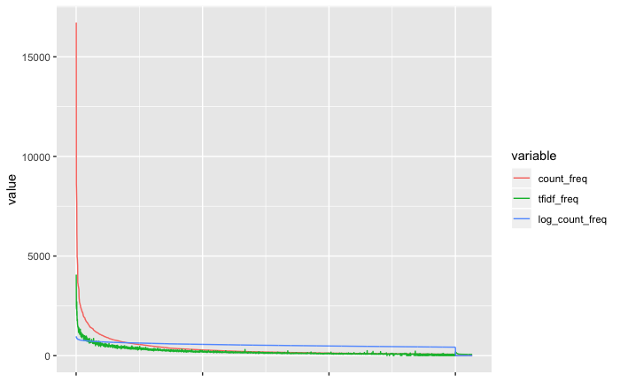

```r
freq_melted$word <- as.numeric(freq_melted$word) #allow to plot on axis
ggplot(freq_melted, aes(x=word, y=value, col=variable)) +
  geom_line() +
  theme(axis.title.x=element_blank(), axis.text.x=element_blank())
```

The TF-IDF model definitely seems to think that some words that appear less frequently overall but in more documents might matter more. That being, let’s use the top TF-IDF words that as our model vocabulary, and choose 1000 words to define our vocabulary

```r
vocab = head(tf_all, 1000)$term
vocab
```

```
   [1] "trump"           "impeach"         "say"             "new"             "presid"          "democrat"        "will"
   [8] "report"          "hous"            "year"            "one"             "peopl"           "just"            "get"
  [15] "now"             "time"            "make"            "call"            "can"             "like"            "whi"
  [22] "elect"           "state"           "want"            "american"        "day"             "polit"           "show"
  [29] "said"            "biden"           "world"           "take"            "watch"           "hear"            "news"
  [36] "republican"      "look"            "ukrain"          "first"           "week"            "back"            "white"
  [43] "live"            "need"            "protest"         "today"           "come"            "right"           "plan"
  [50] "two"             "chang"           "kill"            "campaign"        "work"            "china"           "nation"
  [57] "use"             "know"            "donald"          "offici"          "polic"           "investig"        "dont"
  [64] "america"         "talk"            "senat"           "deal"            "help"            "former"          "think"
  [71] "govern"          "best"            "way"             "good"            "attack"          "war"             "vote"
  [78] "court"           "man"             "even"            "may"             "fire"            "countri"         "claim"
  [85] "climat"          "end"             "million"         "public"          "stori"           "ask"             "warren"
  [92] "thing"           "support"         "power"           "question"        "compani"         "offic"           "break"
  [99] "school"          "tri"             "write"           "befor"           "last"            "media"           "read"
```

[output cut: 128 more lines]

Now that we’ve chosen the words we want to focus most on, let’s see how differently biased sources use them.

To do this, let’s look at frequency comparisons and how average tweet sentiment for each word changes with bias

We’ll now encode our tweets depending on our vocabulary

```r
encode_tweets = function(input_df, input_vocab){
  vocab_len = length(input_vocab)
  vocab_count <- data.frame(matrix(ncol = (2 + vocab_len), nrow = nrow(input_df)))
  vocab_count <- mutate_all(vocab_count, ~replace(., is.na(.), 0))
  freq_sent_cols <- c("bias", "sent", paste(input_vocab))
  colnames(vocab_count) <- freq_sent_cols

  for (row in seq(1:nrow(input_df))) {
    vocab_count[row, 1] = as.double(input_df[row, "bias"])
    vocab_count[row, 2] = as.double(input_df[row, "sent"])
    split_text = str_split(input_df[row, "text"], " ")
    for (tweet in split_text) {
      for (word in tweet) {
        if (word %in% input_vocab) {
          vocab_count[row, match(word, input_vocab) + 2] = 1
        }
      }
    }
  }
  return(vocab_count)
}
```

We’ll now create a function that builds and evaluates a model for us:

```r
eval_rf = function(input_training, input_test, n_trees) {
  rf = ranger(var_1 ~ ., data=input_training, num.trees = n_trees)
  return(predict(rf, input_test))
}
```

```r
training_encoded = encode_tweets(training_set, vocab)
```

Wow, so those are also large. I’m gonna save them so I don’t have to rerun that.

```r
fwrite(training_encoded, "./training_encoded.csv")
fwrite(test_encoded, "./test_encoded.csv")
```

And a re-read:

```r
training_encoded = fread("./training_encoded.csv")
test_encoded = fread("./test_encoded.csv")
```

```r
new_col_names <- c(unlist(str_split(paste(c("",  c(1:length(colnames(training_encoded)))), collapse=" var_"), " ")))
new_col_names <- new_col_names[-1]
colnames(training_encoded) <- new_col_names
colnames(test_encoded) <- new_col_names
```

```r
rf_preds = eval_rf(training_encoded, test_encoded, 500)
```

```
Computing prediction error.. Progress: 48%. Estimated remaining time: 33 seconds.
Computing prediction error.. Progress: 93%. Estimated remaining time: 4 seconds.
Predicting.. Progress: 65%. Estimated remaining time: 16 seconds.
```

```r
score_accuracy = function(test_df, preds) {
  bias_accuracy_df = data.frame(matrix(ncol = (2), nrow = 5))
  bias_accuracy_df <- mutate_all(bias_accuracy_df, ~replace(., is.na(.), 0))
  colnames(bias_accuracy_df) <- c("total_bias_differential", "tweets_in_bias_category")
  for (row_ind in seq(1:nrow(test_df))) {
    #convert to integer then compare to 1.) make this a classification problem, 2.) make filling in accuracy_df easier
    est = round(as.double(preds[row_ind]) * 4) + 1
    actual = (as.double(test_df[row_ind, "var_1"]) * 4) + 1
    bias_diff = ((as.double(actual - est) - 1) / 4)
    if (!is.na(bias_diff)) {
      bias_accuracy_df[actual, 1] = bias_accuracy_df[actual, 1] + bias_diff
      bias_accuracy_df[actual, 2] = bias_accuracy_df[actual, 2] + 1
    }
  }
  return(bias_accuracy_df)
}
```

```r
accuracy = function(x){sum(diag(x)/(sum(rowSums(x)))) * 100}
```

```r
head(rf_preds$predictions, 10)
```

```
 [1] 0.4053638 0.6275717 0.6512830 0.5778621 0.4878274 0.5450382 0.7833912 0.4500146 0.3994300 0.5584356
```

```r
rf_table <- table(round((rf_preds$predictions) * 4) + 1, (test_encoded$var_1 * 4) + 1)
rf_table
```

```
        1     2     3     4     5
  1   615     0     0     0     0
  2  2020  1725   484    95   137
  3  2631  4230 10440  2503  3334
  4   437   417  1193  1399  4145
  5    10    13    14    34  1259
```

```r
accuracy(rf_table)
```

```
[1] 41.57264
```

```r
accuracy_df = score_accuracy(test_encoded, rf_preds$predictions)
accuracy_df %>% mutate(average=(total_bias_differential/tweets_in_bias_category))
```

| total_bias_differential | tweets_in_bias_category | average |
| --- | --- | --- |
| -3586.50 | 5713 | -0.62777875 |
| -2872.00 | 6385 | -0.44980423 |
| -3217.00 | 12131 | -0.26518836 |
| -343.00 | 4031 | -0.08509055 |
| 587.25 | 8875 | 0.06616901 |

It looks like the model is averaging toward words that are too central. We need to make our vocabulary based on words that push towards the ends of the spectrum.

```r
get_sent_col_diff = function(input_col) {
  input_col[6] = abs(input_col[1] - input_col[3]) + .75 * abs(input_col[1] - input_col[3])
  input_col[7] = abs(input_col[5] - input_col[3]) + .75 * abs(input_col[5] - input_col[2])
  return(input_col)
}

get_sent_stats = function(input_df, input_vocab){
  vocab_len = length(input_vocab)
  vocab_count <- data.frame(matrix(ncol = (1 + 2 * vocab_len), nrow = 7))
  vocab_count <- mutate_all(vocab_count, ~replace(., is.na(.), 0))
  freq_sent_cols <- c("bias", paste(input_vocab), unlist(str_split(paste(c(paste(input_vocab), ""), collapse="_sent "), " ")))
  freq_sent_cols <- freq_sent_cols[-length(freq_sent_cols)]
  colnames(vocab_count) <- freq_sent_cols

  for (row in seq(1:nrow(input_df))) {
    bias  <- as.double(input_df[row, "bias"])
    sent <- as.double(input_df[row, "sent"])
    split_text = str_split(input_df[row, "text"], " ")
    for (tweet in split_text) {
      for (word in tweet) {
        if (word %in% input_vocab) {
          match_val =  match(word, input_vocab) + 1
          bias_val = (bias * 4) + 1
          vocab_count[bias_val, match_val] = vocab_count[bias_val, match_val] + 1
          vocab_count[bias_val, match_val + vocab_len] = vocab_count[bias_val, match_val + vocab_len] + sent
        }
      }
    }
  }

  vocab_count$bias <- c(0, 0.25, 0.5, 0.75, 1, 2, 3)
  #average out sentiments
  for(i in 2:(ncol(vocab_count)/2)){
    vocab_count[,i + vocab_len] = (vocab_count[,i + vocab_len] / vocab_count[,i])
    vocab_count[,i + vocab_len] = get_sent_col_diff(vocab_count[,i + vocab_len])
  }
  vocab_count[is.na(vocab_count)] <- 0

  return(vocab_count)
}
```

To get the words that are most polarized, we’ll find the words that the ends of the spectrum use most differently than the center-leaning sources. This metric will also ideally filter out news-type words like ‘reporting’ or ‘live’ that would have no real indication of bias but were included because of a high frequency.

I’m also choosing not to compare the far left to the far right to 1.) try to get my model to explicitly differentiate the ends of the spectrums from the center 2.) to account for any anti-establishment bias both biased sides might have (disliking the Democratic party for being either too liberal or not liberal enough.)

```r
training_sent_stats = get_sent_stats(training_set, vocab)
training_sent_stats$trump_sent
training_sent_stats$impeach_sent
training_sent_stats$democrat_sent
training_sent_stats$protest_sent
training_sent_stats = data.frame(t(training_sent_stats))
```

```r
colnames(training_sent_stats) <- c("v_l", "l_l", "c", "l_r", "v_r", "l_diff", "r_diff")
training_sent_stats = training_sent_stats[-1,]
top_left_sent_diff = training_sent_stats %>% rownames_to_column('word') %>% top_n(100, l_diff) %>% arrange(desc(l_diff))
top_right_sent_diff = training_sent_stats %>% rownames_to_column('word') %>% top_n(100, r_diff) %>% arrange(desc(r_diff))
top_left_sent_diff
top_right_sent_diff
```

```r
sent_diff_vocab = c(substr(top_left_sent_diff$word,1,nchar(top_left_sent_diff$word)-5), substr(top_right_sent_diff$word,1,nchar(top_right_sent_diff$word)-5))
sent_diff_vocab
```

```r
sent_training_encoded = encode_tweets(training_set, sent_diff_vocab)
sent_test_encoded = encode_tweets(test_set, sent_diff_vocab)

new_col_names <- c(unlist(str_split(paste(c("",  c(1:length(colnames(sent_training_encoded)))), collapse=" var_"), " ")))
new_col_names <- new_col_names[-1]
colnames(sent_training_encoded) <- new_col_names
colnames(sent_test_encoded) <- new_col_names
```

Same as before, gonna save them so I don’t have to rerun that block ever.

```r
fwrite(sent_training_encoded, "./sent_training_encoded.csv")
fwrite(sent_test_encoded, "./sent_test_encoded.csv")
```

And a re-read:

```r
sent_training_encoded = fread("./sent_training_encoded.csv")
sent_test_encoded = fread("./sent_test_encoded.csv")
```

```r
sent_training_temp = sent_training_encoded[sample(nrow(sent_training_encoded), 30000), ]
sent_test_temp = sent_test_encoded[sample(nrow(sent_test_encoded), 7500), ]
sent_preds = eval_rf(sent_training_encoded, sent_test_encoded, 500)
```

```r
sent_rf_table <- table(round((sent_preds$predictions) * 4) + 1, (sent_test_encoded$var_1 * 4) + 1)
sent_rf_table
accuracy(sent_rf_table)

accuracy_df = score_accuracy(sent_test_encoded, sent_preds$predictions)
accuracy_df  %>% mutate(average=(total_bias_differential/tweets_in_bias_category))
```

[output not shown]

```r
train_knn_tr = sent_training_encoded[sample(nrow(sent_training_encoded), 30000), ]
test_knn_tr = sent_test_encoded[sample(nrow(sent_test_encoded), 7500), ]
```

```r
knn_predictions <- knn(train_knn_tr, test_knn_tr, train_knn_tr$var_1, k=2)

knn_table <- table(knn_predictions, test_knn_tr$var_1)
accuracy(knn_table)
```

[output not shown]

```r
#svm wants integer labels:
train_svm = train_knn_tr %>% mutate(var_1=((var_1*4) + 1))
test_svm = test_knn_tr %>% mutate(var_1=((var_1*4) + 1))

train_svm = head(train_svm, 3000)
test_svm = head(test_svm, 1000)
test_actual = test_svm$var_1

unscaled_labels = train_svm$var_1
scale_train = data.frame(scale(as.matrix(train_svm))) %>% mutate_all(~replace(., is.na(.), 0))
scale_test = data.frame(scale(as.matrix(test_svm))) %>% mutate_all(~replace(., is.na(.), 0))
scale_train$var_1 = as.integer(unscaled_labels)

svm_model <- ksvm(var_1~., data=scale_train, type="C-svc", kernel="rbfdot", prob.model=TRUE)

svm_pred_df = data.frame(predict(svm_model, scale_test[,-1], type="probabilities"))

for (i in seq(1:nrow(svm_pred_df))) {
  curr_row = c(svm_pred_df[i,1], svm_pred_df[i,2], svm_pred_df[i,3], svm_pred_df[i,4], svm_pred_df[i,5])
  svm_pred_df[i,6] = which.max(curr_row)
}
```

```r
svm_pred_df
```

```r
svm_table <- table(svm_pred_df$V6, test_actual)
svm_table
accuracy(svm_table)
```

[output not shown]

Neural nets, anyone?

```r
library(keras)
```

```r
train_x_keras = train_svm[,-1]
train_y_keras = to_categorical(train_svm[,1])[,-1]
test_x_keras = test_svm[,-1]
test_y_keras = to_categorical(test_svm[,1])[,-1]




dim(train_x_keras)
```

[output not shown]

```r
dim(train_y_keras)
```

[output not shown]

```r
min_col = min(train_x_keras$var_2)
max_col = max(train_x_keras$var_2)
t_train_y = head(train_y_keras, 8000)
t_test_y = head(test_y_keras, 2000)
t_1_train = head(train_x_keras, 8000) %>% mutate(var_2 = ((var_2-min_col)/(max_col-min_col)))
t_1_test = head(test_x_keras, 2000) %>% mutate(var_2 = ((var_2-min_col)/(max_col-min_col)))
t_2_train = data.frame(scale(as.matrix(head(train_x_keras, 8000))))
t_2_test = data.frame(scale(as.matrix(head(test_x_keras, 2000))))
```

```r
keras_eval_model = function(keras_model, train_x, train_y, test_x, test_y) {
  history <- keras_model %>% fit(
    train_x, train_y,
    epochs = 40, batch_size = 20,
    validation_split = 0.2
  )
  plot(history)

  return(keras_model %>% evaluate(test_x, test_y, verbose = 0))
}

keras_model_vanilla <- keras_model_sequential()
keras_model_vanilla %>%
  layer_dense(units = 512, activation = "relu", input_shape = c(201)) %>%
  layer_dense(units = 512, activation = "relu") %>%
  layer_dense(units = 256, activation = "relu") %>%
  layer_dense(units = 5, activation = "softmax")

keras_model_vanilla %>% compile(
  loss = "categorical_crossentropy",
  optimizer = optimizer_sgd(lr = 0.001, nesterov=TRUE),
  metrics = c("accuracy")
)

keras_eval_model(keras_model_vanilla, as.matrix(t_2_train), as.matrix(t_train_y), as.matrix(t_2_test), as.matrix(t_test_y))
```

[output not shown]

```r
keras_model_dropout <- keras_model_sequential()
keras_model_regulaizer <- keras_model_sequential()

keras_model_dropout %>%
  layer_dense(units = 1024, activation = "relu", input_shape = c(201)) %>%
  layer_dense(units = 512, activation = "relu") %>%
  layer_dropout(rate = 0.3) %>%
  layer_dense(units = 256, activation = "relu") %>%
  layer_dropout(rate = 0.3) %>%
  layer_dense(units = 5, activation = "softmax")

keras_model_regulaizer %>%
  layer_dense(units = 1024, activation = "relu", input_shape = c(201), kernel_regularizer = regularizer_l2(l = 0.001)) %>%
  layer_dense(units = 512, activation = "relu", kernel_regularizer = regularizer_l2(l = 0.001)) %>%
  layer_dense(units = 256, activation = "relu") %>%
  layer_dense(units = 5, activation = "softmax")

dropout_sgd <- keras_model_dropout
regulaizer_sgd <- keras_model_regulaizer
dropout_adagrad <- keras_model_dropout
regulaizer_adagrad <- keras_model_regulaizer

dropout_sgd %>% compile(
  loss = "categorical_crossentropy",
  optimizer = optimizer_sgd(lr = 0.001, momentum = 0, decay = 0),
  metrics = c("accuracy")
)

regulaizer_sgd %>% compile(
  loss = "categorical_crossentropy",
  optimizer = optimizer_sgd(lr = 0.001, momentum = 0, decay = 0),
  metrics = c("accuracy")
)


dropout_adagrad %>% compile(
  loss = "categorical_crossentropy",
  optimizer = optimizer_adagrad(lr = 0.001, decay = 0),
  metrics = c("accuracy")
)

regulaizer_adagrad %>% compile(
  loss = "categorical_crossentropy",
  optimizer = optimizer_adagrad(lr = 0.001, decay = 0),
  metrics = c("accuracy")
)
```

```r
keras_eval_model(regulaizer_sgd, as.matrix(train_x_keras), as.matrix(train_y_keras), as.matrix(test_x_keras), as.matrix(test_y_keras))
```

[output not shown]